# Health and Nutrition Analysis

The dataset that I chose to investigate was tbe National Health and Nutrition Health Survey 2013-2014 (NHANES) Age Prediction Subset dataset. It contained the age group of individuals and a variety of diabetes-related health data points about them. From those data points, my goal was to predict whether or not an individual is a Senior or an Adult. Along the way, I also aim to investigate which health data points are the most important when determining whether or not someone is a Senior.

This analysis will help us answer two questions:

What health metrics are most indicative of being in the Senior age group?

Can age group be predicted using simple health metrics?

```python
! pip install ucimlrepo
```

```
Downloading ucimlrepo-0.0.7-py3-none-any.whl (8.0 kB)
```

```python
import pandas as pd
from ucimlrepo import fetch_ucirepo

# Accessing the dataset and storing it in a dataframe
data = fetch_ucirepo(id=887)

X = data.data.features
y = data.data.targets

# Concatenating the features and targets for preprocessing
all_data = pd.concat([X, y], axis=1)

print(data.metadata)
```

```
{'uci_id': 887, 'name': 'National Health and Nutrition Health Survey 2013-2014 (NHANES) Age Prediction Subset', 'repository_url': 'https://archive.ics.uci.edu/dataset/887/national+health+and+nutrition+health+survey+2013-2014+(nhanes)+age+prediction+subset', 'data_url': 'https://archive.ics.uci.edu/s…
```

# Preprocessing

```python
# Ensuring that there are no na values in the dataset
na_columns = all_data.isna().sum()
print(na_columns.to_string())
```

```
RIAGENDR     0
PAQ605       0
BMXBMI       0
LBXGLU       0
DIQ010       0
LBXGLT       0
LBXIN        0
age_group    0
```

Decoding the dataset:

BMXBMI: Respondent's Body Mass Index

LBXGLU: Respondent's Blood Glucose after fasting

LBXGLT: Respondent's Oral Glucose Tolerance Test Results

LBXIN: Respondents's Blood Insulin Levels

PAQ605: Does your work involve vigorous activity?

1 - Yes

2 - No

7 - Refused

9 - Don't know

DIQ010: Has the doctor told you that you have diabetes?

1 - Yes

2 - No

3 - Borderline

7 - Refused

9 Don't know

RIAGENDR: What is your gender?

1 - Male

2 - Female

age_group:

Senior or Adult

```python
# Inspecting the dataset
print(all_data.head())
# Ensuring no duplicated data points
print(all_data.duplicated().sum())
# Investigating how balanced the dataset is
print(all_data["age_group"].value_counts())
```

```
   RIAGENDR  PAQ605  BMXBMI  LBXGLU  DIQ010  LBXGLT  LBXIN age_group
0       2.0     2.0    35.7   110.0     2.0   150.0  14.91     Adult
1       2.0     2.0    20.3    89.0     2.0    80.0   3.85     Adult
2       1.0     2.0    23.2    89.0     2.0    68.0   6.14     Adult
3       1.0     2.0    28.9   104.0     2.0    84.0  16.15     Adult
4       2.0     1.0    35.9   103.0     2.0    81.0  10.92     Adult
0
age_group
Adult     1914
Senior     364
Name: count, dtype: int64
```

From this output, we can observe that there are far more Adult labelled data points in the the dataset than Senior labelled points. This is something to take into account when scoring the models later. We want to balance the number of incorrect Adult and Senior predictions as we value correct predictions for each category equally.

In order to properly use the dataset, I looked through the dataset and despite having no NA values, there was a data point in the 'PAQ605' stat that represented a refusal response in the survey that the data came from, so I replaced its value with the mode of the category, as that represents the most likely category for that individual to fall into.

```python
# Checking for invalid values
print(all_data['PAQ605'].value_counts())
all_data['PAQ605'] = all_data['PAQ605'].replace(7.0, all_data['PAQ605'].mode()[0])
print(all_data['PAQ605'].value_counts())
```

```
PAQ605
2.0    1868
1.0     409
7.0       1
Name: count, dtype: int64
PAQ605
2.0    1869
1.0     409
Name: count, dtype: int64
```

```python
print(all_data['DIQ010'].value_counts())
```

```
DIQ010
2.0    2199
3.0      58
1.0      21
Name: count, dtype: int64
```

I created dummy variables for each of the categorical variables and then dropped the first of each one in order to preserve the categorical information properly and avoid perfect multicollinearity.

```python
all_data_encoded_drop_first = pd.get_dummies(all_data, columns=['RIAGENDR', 'PAQ605', 'age_group', 'DIQ010'], drop_first=True)
all_data = all_data_encoded_drop_first
all_data.head()
```

|  | BMXBMI | LBXGLU | LBXGLT | LBXIN | RIAGENDR_2.0 | PAQ605_2.0 | age_group_Senior | DIQ010_2.0 | DIQ010_3.0 |
| --- | --- | --- | --- | --- | --- | --- | --- | --- | --- |
| 0 | 35.7 | 110.0 | 150.0 | 14.91 | True | True | False | True | False |
| 1 | 20.3 | 89.0 | 80.0 | 3.85 | True | True | False | True | False |
| 2 | 23.2 | 89.0 | 68.0 | 6.14 | False | True | False | True | False |
| 3 | 28.9 | 104.0 | 84.0 | 16.15 | False | True | False | True | False |
| 4 | 35.9 | 103.0 | 81.0 | 10.92 | True | False | False | True | False |

```python
# Inspecting the data again
all_data.head()
```

|  | BMXBMI | LBXGLU | LBXGLT | LBXIN | RIAGENDR_2.0 | PAQ605_2.0 | age_group_Senior | DIQ010_2.0 | DIQ010_3.0 |
| --- | --- | --- | --- | --- | --- | --- | --- | --- | --- |
| 0 | 35.7 | 110.0 | 150.0 | 14.91 | True | True | False | True | False |
| 1 | 20.3 | 89.0 | 80.0 | 3.85 | True | True | False | True | False |
| 2 | 23.2 | 89.0 | 68.0 | 6.14 | False | True | False | True | False |
| 3 | 28.9 | 104.0 | 84.0 | 16.15 | False | True | False | True | False |
| 4 | 35.9 | 103.0 | 81.0 | 10.92 | True | False | False | True | False |

I separated the data back out into features and labels to prepare for training and testing.

```python
y = all_data[['age_group_Senior']]
X = all_data.drop(columns=['age_group_Senior'])
```

```python
# Verifying the columns in the features and labels
print(y.columns)
print(X.columns)
```

```
Index(['age_group_Senior'], dtype='object')
Index(['BMXBMI', 'LBXGLU', 'LBXGLT', 'LBXIN', 'RIAGENDR_2.0', 'PAQ605_2.0',
       'DIQ010_2.0', 'DIQ010_3.0'],
      dtype='object')
```

```python
from sklearn.model_selection import train_test_split

X_train, X_test, y_train, y_test = train_test_split(X, y, stratify=y,
                                                    random_state=495)
```

# Random Forest

The first way I decided to approach the data was with was a Random Forest, as it is well suited for dealing with complex relationships within the data due to it being an ensemble model, and it also has the ability to work well with an imbalanced dataset when balanced class weighting is applied. From here I decided to do a Randomized Search to find the optimal parameters in a reasonable amount of time. I optimized my Randomized Search for the F1 Score in order to value the correctness of both True Positives and True Negatives equally as the dataset is imbalanced. I chose F1 score over Precision or Recall because I don't value predicting if one person is a Senior more than I value predicting a person is an Adult despite the dataset being imbalanced towards the Adult class.

I used all of these parameters in my random search because I wanted to create a wide variety of forest from which the best could be chosen. Specifically I tuned the ranges of 'n_estimators,' 'max_depth,' and 'min_samples_split' in the parameters to discourage any potential forests from overfitting.

Also, I scored the models during cross validation in both F1 Score and Accuracy to keep track of their performance across the different folds in order to make sure I wasn't sacrificing too much Accuracy for the F1 Score increases.

As an aside, I first did testing while searching for the highest accuracy model, but the results had many False Negatives similar to the MLP PCA model down below, making them not particularly useful.

```python
import numpy as np
from sklearn.model_selection import RandomizedSearchCV
import matplotlib.pyplot as plt
from sklearn.ensemble import RandomForestClassifier
from sklearn.metrics import make_scorer, f1_score, accuracy_score


param_dist = {
    'n_estimators': np.arange(25, 400, 25),
    'max_depth': np.arange(5, 10, 5),
    'min_samples_split': np.arange(2, 25, 2),
    'min_samples_leaf': np.arange(2, 20, 2),
    'max_features': ['sqrt', 'log2', None],
    'bootstrap': [True, False],
}

scoring = {
    'accuracy': make_scorer(accuracy_score),
    'f1': make_scorer(f1_score)
}

forest = RandomForestClassifier(random_state=495, class_weight='balanced')

random_search = RandomizedSearchCV(forest, param_distributions=param_dist, n_iter=200, cv=5,
                                   verbose=0, random_state=495, n_jobs=-1, scoring=scoring,
                                   refit = 'f1')

random_search.fit(X_train, y_train)

best_params = random_search.best_params_
best_forest = random_search.best_estimator_

print(best_params)
```

```
{'n_estimators': 275, 'min_samples_split': 4, 'min_samples_leaf': 14, 'max_features': None, 'max_depth': 5, 'bootstrap': True}
```

```python
# Inspeciting the Accuracy and F1 Score from during the Randomized Search
print("Randomized Search Cross-validation results:")
print(random_search.cv_results_['mean_test_accuracy'].max())
print(random_search.cv_results_['mean_test_f1'].max())
```

```
Randomized Search Cross-validation results:
0.7529334087907943
0.4449989436523654
```

```python
# Checking to see if the model is severly overfit, which it is not
print("Accuracy on training set: {:.3f}".format(best_forest.score(X_train, y_train)))
print("Accuracy on test set: {:.3f}".format(best_forest.score(X_test, y_test)))
```

```
Accuracy on training set: 0.765
Accuracy on test set: 0.702
```

After determining my final model, I checked its performance on the training and test datasets. Then I checked its other metrics.

```
Testing Metrics:
Accuracy: 0.7017543859649122
Precision: 0.2931937172774869
Recall: 0.6153846153846154
F1 Score: 0.3971631205673759
Confusion matrix:
[[344 135]
 [ 35  56]]
```

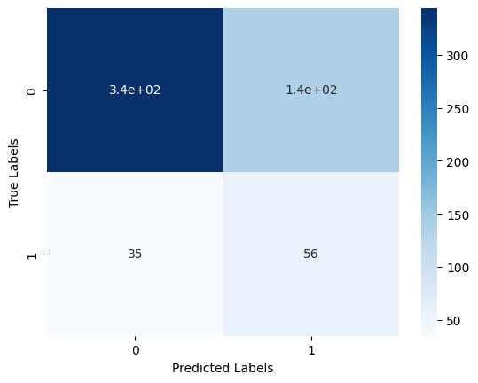

```python
from sklearn.metrics import confusion_matrix
import seaborn as sns
from sklearn.metrics import precision_score, recall_score


# Random Forest
y_pred = best_forest.predict(X_test)
print("Testing Metrics:")
print("Accuracy:", accuracy_score(y_test, y_pred))
print("Precision:", precision_score(y_test, y_pred))
print("Recall:", recall_score(y_test, y_pred))
print("F1 Score:", f1_score(y_test, y_pred))


cm = confusion_matrix(y_test, y_pred)
print("Confusion matrix:\n{}".format(cm))
sns.heatmap(cm, annot=True, cmap='Blues', cbar=True)
plt.xlabel("Predicted Labels")
plt.ylabel("True Labels")
```

The AUC ROC curve was also somewhat promising, showing a significant increase in performance above just guessing.

```
AUROC: 0.7437426873752553
```

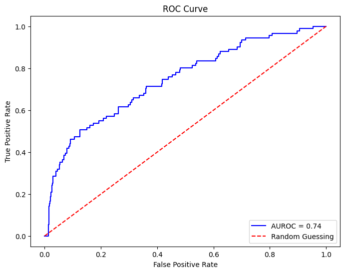

```python
from sklearn.metrics import roc_auc_score, roc_curve

# best_forest
y_prob = best_forest.predict_proba(X_test)[:, 1]

auroc = roc_auc_score(y_test, y_prob)
print("AUROC:", auroc)

fpr, tpr, thresholds = roc_curve(y_test, y_prob)
plt.figure(figsize=(8, 6))
plt.plot(fpr, tpr, color='blue', label=f"AUROC = {auroc:.2f}")
plt.plot([0, 1], [0, 1], color='red', linestyle='--', label="Random Guessing")
plt.xlabel("False Positive Rate")
plt.ylabel("True Positive Rate")
plt.title("ROC Curve")
plt.legend(loc="lower right")
plt.show()
```

The F1-Score ended up being 0.397, and there were many false positives. Simoultaneously, almost 2/3s of the positive test values were also predicted to be true. The Accuracy was still decent, but the Precision was distinctly worse than the Recall.

Then I checked the cross validation results with Stratified K Fold due to the imbalanced dataset and found that the model performed similarly across all 5 splits, showing that the model was generalizeable.

```python
from sklearn.model_selection import StratifiedKFold
from sklearn.model_selection import cross_val_score

skf = StratifiedKFold(n_splits=5, shuffle=True, random_state=495)
scores = cross_val_score(best_forest, X, y, cv=skf, scoring='f1')
print("Cross-validation scores:\n{}".format(scores))
```

```
Cross-validation scores:
[0.36619718 0.4279476  0.42666667 0.40414508 0.4057971 ]
```

I decided to look at the predictive power of each feature and found that Gender and Diabetes Diagnosis had very little predictive power within the Random Forest.

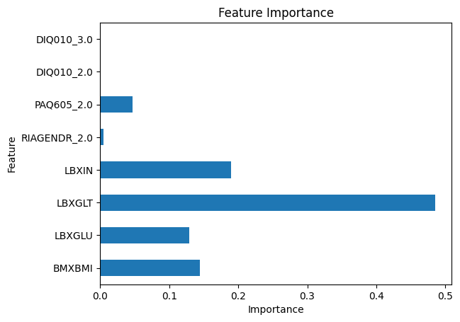

```python
# Plotting the importance of each feature
importances = best_forest.feature_importances_
feature_names = X.columns

importance_df = pd.DataFrame({
    'Feature': feature_names,
    'Importance': importances
})

importance_df.plot(kind='barh', x='Feature', y='Importance', legend=False)
plt.title('Feature Importance')
plt.xlabel('Importance')
plt.ylabel('Feature')
plt.show()
```

In order to verify these finidings, I used Recursive Feature Elimination to create tree with the least important features removed one at a time and found that with Gender and Diabetes Diagnosis removed the Random Forest performs just as well in Cross Validation and all of the performance metrics are essentially the same.

This shows that Gender and Diabetes Diagnosis are not indicative of old age which matches the intuition that, even though women live longer than men, Gender isn't a strong indicator of old age, and even though types of diabetes develop throughout life, it also isn't a strong indicator.

```
[[ 35.7  110.   150.    14.91   1.  ]
 [ 20.3   89.    80.     3.85   1.  ]
 [ 23.2   89.    68.     6.14   1.  ]
 [ 28.9  104.    84.    16.15   1.  ]
 [ 35.9  103.    81.    10.92   0.  ]]
```

```
Testing Metrics:
Accuracy: 0.7017543859649122
Precision: 0.2931937172774869
Recall: 0.6153846153846154
F1 Score: 0.3971631205673759
Confusion matrix:
[[344 135]
 [ 35  56]]
```

```
Cross-validation scores:
[0.37383178 0.42982456 0.42477876 0.40837696 0.41148325]
```

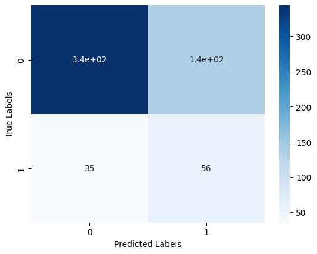

```python
from sklearn.feature_selection import RFE

# Testing random forests with less importance features removed
selector = RFE(estimator=best_forest, n_features_to_select=5, step=1)
selector = selector.fit(X, y)
X_selected = selector.transform(X)

print(X_selected[:5])
X_train_selected, X_test_selected, y_train, y_test = train_test_split(X_selected, y, stratify=y,
                                                    random_state=495)

best_forest.fit(X_train_selected, y_train)

y_pred = best_forest.predict(X_test_selected)

print("Testing Metrics:")
print("Accuracy:", accuracy_score(y_test, y_pred))
print("Precision:", precision_score(y_test, y_pred))
print("Recall:", recall_score(y_test, y_pred))
print("F1 Score:", f1_score(y_test, y_pred))

cm = confusion_matrix(y_test, y_pred)
print("Confusion matrix:\n{}".format(cm))
sns.heatmap(cm, annot=True, cmap='Blues', cbar=True)
plt.xlabel("Predicted Labels")
plt.ylabel("True Labels")

skf = StratifiedKFold(n_splits=5, shuffle=True, random_state=495)
scores = cross_val_score(best_forest, X_selected, y, cv=skf, scoring='f1')
print("Cross-validation scores:\n{}".format(scores))
```

```
AUROC: 0.743306797586547
```

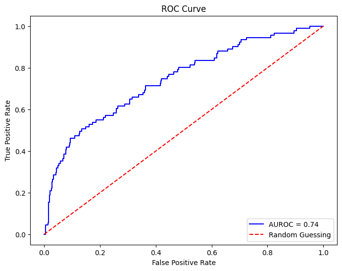

```python
X_test_temp = X_test.drop(columns=["RIAGENDR_2.0", "DIQ010_2.0", "DIQ010_3.0"])

y_prob = best_forest.predict_proba(X_test_temp)[:, 1]

auroc = roc_auc_score(y_test, y_prob)
print("AUROC:", auroc)

fpr, tpr, thresholds = roc_curve(y_test, y_prob)
plt.figure(figsize=(8, 6))
plt.plot(fpr, tpr, color='blue', label=f"AUROC = {auroc:.2f}")
plt.plot([0, 1], [0, 1], color='red', linestyle='--', label="Random Guessing")
plt.xlabel("False Positive Rate")
plt.ylabel("True Positive Rate")
plt.title("ROC Curve")
plt.legend(loc="lower right")
plt.show()
```

# Multilayer Perceptron

Next, as a point of comparison, I decided to use Multilayer Perceptron models to predict the labels of the dataset. Based on my previous experience, I knew that they were good at determining complex relationships, and I thought that might be helpful when solving this problem due to the complex relationships between health metrics and age. First, I needed to scale the data because MLPs perform best if the data is normalized, so I applied the MinMaxScaler to the data. I also removed the variables found by the Random Forest to not have any predictive power in order to reduce the noise for the model and improve performance.

```python
from sklearn.preprocessing import StandardScaler, MinMaxScaler

all_data = all_data.drop(columns=["RIAGENDR_2.0", "DIQ010_2.0", "DIQ010_3.0"])

scaler = MinMaxScaler()
data_scaled = scaler.fit_transform(all_data[['BMXBMI', 'LBXGLU', 'LBXGLT', 'LBXIN']])
print(type(data_scaled))
data_scaled = pd.DataFrame(data_scaled, columns=['BMXBMI', 'LBXGLU', 'LBXGLT', 'LBXIN'])

data_copy = all_data.copy()

data_copy[['BMXBMI', 'LBXGLU', 'LBXGLT', 'LBXIN']] = data_scaled[['BMXBMI', 'LBXGLU', 'LBXGLT', 'LBXIN']]
print(data_copy.head())
X_scaled = data_copy.drop(columns=['age_group_Senior'])

X_train_scaled, X_test_scaled, y_train, y_test = train_test_split(X_scaled, y, stratify=y,
                                                    random_state=495)
```

```
<class 'numpy.ndarray'>
     BMXBMI    LBXGLU    LBXGLT     LBXIN  PAQ605_2.0  age_group_Senior
0  0.381295  0.137427  0.195035  0.144591        True             False
1  0.104317  0.076023  0.070922  0.036319        True             False
2  0.156475  0.076023  0.049645  0.058737        True             False
3  0.258993  0.119883  0.078014  0.156730        True             False
4  0.384892  0.116959  0.072695  0.105531       False             False
```

Then I ran multiple Grid Searches in order to find the hyperparameters that maximized the model's F1 Score. I chose Grid Search because I wanted to make sure that I considered all of the possible hyperparameters for each hidden layer architecture because the performance difference between architecture can be large with different parameters.

I tried both simpler and more complex model architectures, some with layers that decreased in size further into the model, some that remained at the sample level of complexity throughout. I also tested different activation functions and solver algorithms in order to mach the correct combination to the problem. I also expermented with different amounts of regularization with 'alpha' in order to limit overfitting. I also tried different types of learning rates to ensure that no potetntial solution was missed with too high or too low of a learning rate.

There were more hyperparameters searched through than the ones seen below, but these were the last ones I tested.

```python
from sklearn.model_selection import GridSearchCV
from sklearn.neural_network import MLPClassifier

param_grid = {
    'hidden_layer_sizes': [(50,), (50, 50), (100, 50, 25), (25, 25)],
    'activation': ['tanh', 'relu'],
    'solver': ['adam', 'lbfgs'],
    'alpha': [0.0001, 0.001],
    'learning_rate': ['constant', 'adaptive'],
    'learning_rate_init': [0.0001, 0.001],
}

mlp = MLPClassifier(max_iter=2000, random_state=495, early_stopping=True)

grid_search = GridSearchCV(mlp, param_grid, cv=5, n_jobs=-1, verbose=0, scoring = 'f1')


grid_search.fit(X_train_scaled, y_train)

best_params = grid_search.best_params_
best_model = grid_search.best_estimator_

print(f"Best parameters found: {best_params}")

y_pred = best_model.predict(X_test_scaled)
accuracy = accuracy_score(y_test, y_pred)
print(accuracy)
```

```
Best parameters found: {'activation': 'relu', 'alpha': 0.001, 'hidden_layer_sizes': (25, 25), 'learning_rate': 'constant', 'learning_rate_init': 0.0001, 'solver': 'lbfgs'}
0.8070175438596491
```

I tried different batch sizes in order to find a good balance between time spent converging on a solution and noise created finding that solution. I also tried different momentum and tolerance values because they can effect the local minima that an MLP will find and which ones that it will stop at.

There were more hyperparameters searched through than the ones seen below, but these were the last ones I tested.

```python
param_grid = {
    'batch_size': ['auto', 32, 64, 128],
    'momentum': [0.5, 0.7, 0.9, 0.99],
    'tol': [0.0001, 0.001, 0.01],
}

mlp = MLPClassifier(max_iter=2000, random_state=495, early_stopping=True, activation="relu",
                    alpha=0.001, hidden_layer_sizes=(100, 50, 25), learning_rate="constant",
                    learning_rate_init=0.0001, solver="lbfgs")

grid_search = GridSearchCV(mlp, param_grid, cv=5, n_jobs=-1, verbose=0, scoring='f1')

grid_search.fit(X_train_scaled, y_train)

best_params = grid_search.best_params_
best_model = grid_search.best_estimator_

print(f"Best parameters found: {best_params}")

y_pred = best_model.predict(X_test_scaled)
accuracy = accuracy_score(y_test, y_pred)

print(accuracy)
```

```
Best parameters found: {'batch_size': 'auto', 'momentum': 0.5, 'tol': 0.0001}
0.8192982456140351
```

Then I used a model with the best hyperparameters and cross validated it with Stratified K Fold in order to ensure that its performance was generalizeable to other data, and it appeared to be so. The variance in F1 Score between the folds was quite high but generally it was still close to the original F1 Score.

```python
mlp = MLPClassifier(max_iter=20000, random_state=495, early_stopping=True, activation="relu",
                    alpha=0.001, hidden_layer_sizes=(25, 25), learning_rate="constant",
                    learning_rate_init=0.0001, solver="lbfgs", batch_size='auto', momentum=0.5,
                    tol=0.0001)

mlp.fit(X_train_scaled, y_train)

y_pred = mlp.predict(X_test_scaled)
f1 = f1_score(y_test, y_pred)

print(f1)

skf = StratifiedKFold(n_splits=5, shuffle=True, random_state=495)
scores = cross_val_score(mlp, X_scaled, y, cv=skf, scoring='f1')
print("Cross-validation scores:\n{}".format(scores))
```

```
0.21428571428571427
```

```
Cross-validation scores:
[0.24       0.32727273 0.19148936 0.2970297  0.28      ]
```

Looking at the performance of the model, it's accuracy was still reasonable, but the F1 Score, Recall, and Precision were still quite low. In particular, there were a lot of False Negatives. I believe that this is because the MLP is training to minimize its Cross Entropy Loss which is influenced by the large amount of data points labeled as False for age_group_Senior when training.

```python
print("Accuracy:", accuracy_score(y_test, y_pred))
print("Precision:", precision_score(y_test, y_pred))
print("Recall:", recall_score(y_test, y_pred))
print("F1 Score:", f1_score(y_test, y_pred))
```

```
Accuracy: 0.8070175438596491
Precision: 0.30612244897959184
Recall: 0.16483516483516483
F1 Score: 0.21428571428571427
```

```
Confusion matrix:
[[445  34]
 [ 76  15]]
```

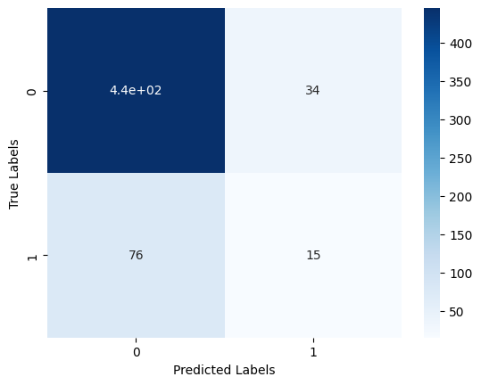

```python
cm = confusion_matrix(y_test, y_pred)
print("Confusion matrix:\n{}".format(cm))
sns.heatmap(cm, annot=True, cmap='Blues', cbar=True)
plt.xlabel("Predicted Labels")
plt.ylabel("True Labels")
```

```
AUROC: 0.6963454082451995
```

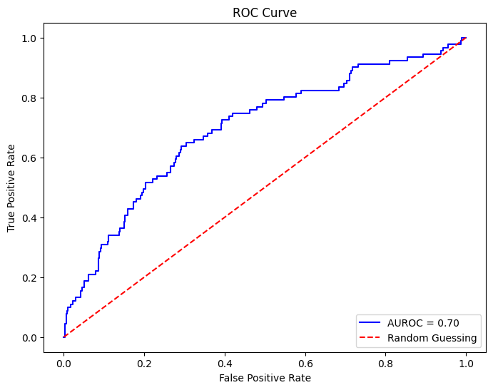

```python
y_proba = mlp.predict_proba(X_test_scaled)[:, 1]

auroc = roc_auc_score(y_test, y_proba)
print("AUROC:", auroc)

fpr, tpr, thresholds = roc_curve(y_test, y_proba)
plt.figure(figsize=(8, 6))
plt.plot(fpr, tpr, color='blue', label=f"AUROC = {auroc:.2f}")
plt.plot([0, 1], [0, 1], color='red', linestyle='--', label="Random Guessing")
plt.xlabel("False Positive Rate")
plt.ylabel("True Positive Rate")
plt.title("ROC Curve")
plt.legend(loc="lower right")
plt.show()
```

In order to counteract this class imbalance, I moved the prediction threshold lower to account for the imbalanced classes in the training dataset, and through my testing I found that a threshold around 0.32 worked the best for maximizing the number of True Positives.

```python
threshold = 0.32
y_pred = (y_proba >= threshold).astype(int)
```

```
Accuracy: 0.775438596491228
Precision: 0.32038834951456313
Recall: 0.3626373626373626
F1 Score: 0.3402061855670103
Confusion matrix:
[[409  70]
 [ 58  33]]
```

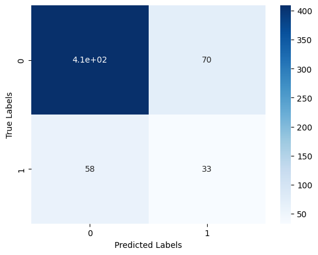

```python
print("Accuracy:", accuracy_score(y_test, y_pred))
print("Precision:", precision_score(y_test, y_pred))
print("Recall:", recall_score(y_test, y_pred))
print("F1 Score:", f1_score(y_test, y_pred))

cm = confusion_matrix(y_test, y_pred)
print("Confusion matrix:\n{}".format(cm))
sns.heatmap(cm, annot=True, cmap='Blues', cbar=True)
plt.xlabel("Predicted Labels")
plt.ylabel("True Labels")
```

From here I was at a loss of where to go next, so I decided to take a long shot on using PCA to improve the insights of my model. I doubted that it would improve performance because I had so many datapoints as it is primarily used to maximize insights from small datasets, but I decided to take a shot anyways. I also decided to do some testing with SMOTE in order to create artificial data to balance the dataset and hopefully glean more insights that way as well.

For the PCA, I had to access the original data again as it works best when the data is standardized not normalized like the MLP. I also grid searched in a similar way when looking for hyperparameters.

```python
from sklearn.pipeline import Pipeline
from sklearn.decomposition import PCA

X =  all_data.drop(columns=['age_group_Senior', "RIAGENDR_2.0", "DIQ010_2.0", "DIQ010_3.0"])

X_train, X_test, y_train, y_test = train_test_split(X, y, stratify=y,
                                                    random_state=495)

pipeline = Pipeline([
    ('scaler', StandardScaler()),
    ('pca', PCA(n_components=3)),
    ('mlp', MLPClassifier( max_iter=10000, random_state=495, early_stopping=True, learning_rate="constant",))
])

param_grid = {
    'mlp__hidden_layer_sizes': [ (100,), (50, 50), (100, 50, 25)],
    'mlp__activation': ['relu', 'logistic'],
    'mlp__solver': ['adam', 'lbfgs'],
    'mlp__alpha': [0.001, 0.01],
    'mlp__learning_rate_init': [0.0001, 0.001],
}

grid_search = GridSearchCV(pipeline, param_grid, cv=5, scoring='f1', n_jobs=-1)

grid_search.fit(X_train, y_train)

best_pca_model = grid_search.best_estimator_

print(grid_search.best_params_)

y_pred = best_pca_model.predict(X_test_scaled)
```

```
{'mlp__activation': 'logistic', 'mlp__alpha': 0.01, 'mlp__hidden_layer_sizes': (100,), 'mlp__learning_rate_init': 0.0001, 'mlp__solver': 'lbfgs'}
```

The model performed poorly with the PCA and failed to consider the smaller class in the training set. As expected, the PCA didn't provide much to add to the model.

[output not shown]

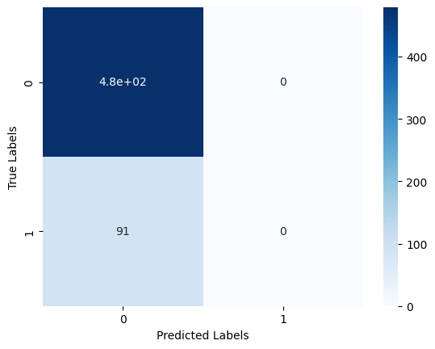

```python
print("Accuracy:", accuracy_score(y_test, y_pred))
print("Precision:", precision_score(y_test, y_pred))
print("Recall:", recall_score(y_test, y_pred))
print("F1 Score:", f1_score(y_test, y_pred))

cm = confusion_matrix(y_test, y_pred)
print("Confusion matrix:\n{}".format(cm))
sns.heatmap(cm, annot=True, cmap='Blues', cbar=True)
plt.xlabel("Predicted Labels")
plt.ylabel("True Labels")
```

Moving on to SMOTE, I applied SMOTE to the training data to resample it and artificially balance the dataset, and then I ran a Grid Search in order to find the best parameters to run on the resampled data, considering fewer in my search due to the time it takes to Grid Search.

```python
from imblearn.over_sampling import SMOTE

smote = SMOTE(random_state=495)
X_train_res, y_train_res = smote.fit_resample(X_train_scaled, y_train)

mlp = MLPClassifier(max_iter=10000, random_state=495, early_stopping=True, learning_rate="constant")

param_grid = {
    'hidden_layer_sizes': [ (100,), (50, 50), (100, 50, 25)],
    'activation': ['relu', 'logistic'],
    'solver': ['adam', 'lbfgs'],
    'alpha': [0.0001, 0.001, 0.01],
    'learning_rate_init': [0.0001, 0.001],
}

grid_search = GridSearchCV(mlp, param_grid, cv=5, scoring='f1', n_jobs=-1, verbose=0)
grid_search.fit(X_train_res, y_train_res)

best_smote_model = grid_search.best_estimator_

print(grid_search.best_params_)

y_pred = best_smote_model.predict(X_test_scaled)
```

```
{'activation': 'logistic', 'alpha': 0.01, 'hidden_layer_sizes': (50, 50), 'learning_rate_init': 0.0001, 'solver': 'lbfgs'}
```

This model performed reasonable well with an F1 Score of 0.3399. It had many False Positives, but also predicted about half of the Positive Labels correctly. This large number of False Positives also made this model have a slightly worse AUROC score than the MLP without SMOTE (0.66 to 0.70), but neither performed as well as the Random Forest with an AUROC of 0.74.

```
Accuracy: 0.7070175438596491
Precision: 0.2654320987654321
Recall: 0.4725274725274725
F1 Score: 0.33992094861660077
Confusion matrix:
[[360 119]
 [ 48  43]]
```

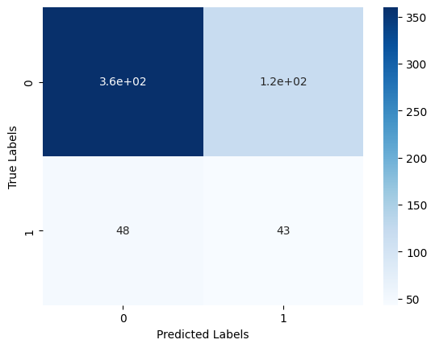

```python
print("Accuracy:", accuracy_score(y_test, y_pred))
print("Precision:", precision_score(y_test, y_pred))
print("Recall:", recall_score(y_test, y_pred))
print("F1 Score:", f1_score(y_test, y_pred))

cm = confusion_matrix(y_test, y_pred)
print("Confusion matrix:\n{}".format(cm))
sns.heatmap(cm, annot=True, cmap='Blues', cbar=True)
plt.xlabel("Predicted Labels")
plt.ylabel("True Labels")
```

```
AUROC: 0.656771203744064
```

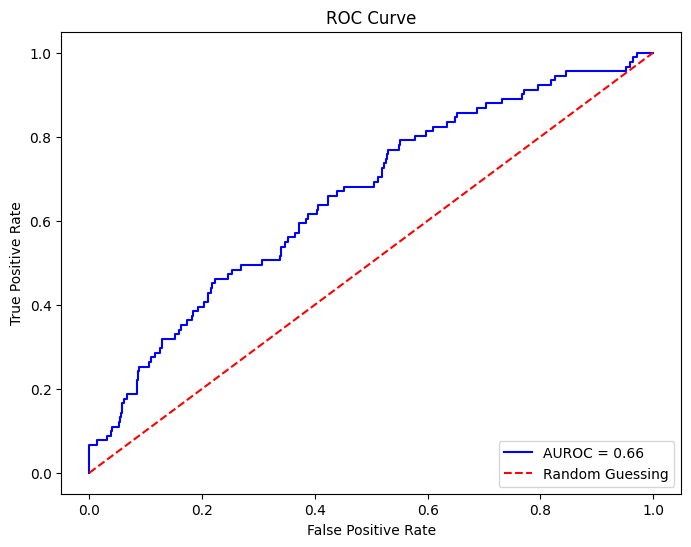

```python
y_proba = best_smote_model.predict_proba(X_test_scaled)[:, 1]

auroc = roc_auc_score(y_test, y_proba)
print("AUROC:", auroc)

fpr, tpr, thresholds = roc_curve(y_test, y_proba)
plt.figure(figsize=(8, 6))
plt.plot(fpr, tpr, color='blue', label=f"AUROC = {auroc:.2f}")
plt.plot([0, 1], [0, 1], color='red', linestyle='--', label="Random Guessing")
plt.xlabel("False Positive Rate")
plt.ylabel("True Positive Rate")
plt.title("ROC Curve")
plt.legend(loc="lower right")
plt.show()
```

Using the hyperparameters found by the Grid Search to be the best for the F1 Score, I checked the Stratified K Fold Cross Validation F1 Scores and found that it was reasonably generalizable. The pipeline is necessary to apply SMOTE correctly to each fold of the cross validation.

```python
from imblearn.pipeline import make_pipeline
smote = SMOTE(random_state=495)
mlp = MLPClassifier(max_iter=10000, random_state=495, early_stopping=True, learning_rate="constant", activation='logistic', alpha=0.01,
                    hidden_layer_sizes= (50, 50), learning_rate_init=0.0001, solver='lbfgs')

pipeline = make_pipeline(smote, mlp)

skf = StratifiedKFold(n_splits=5, shuffle=True, random_state=42)

scores = cross_val_score(pipeline, X_scaled, y, cv=skf, scoring='f1')
```

[output not shown]

```python
# Printing out the mean of the F1 Cross Validation Scores as a point of comparison
print(np.mean(scores))
```

```
0.29156047301453775
```

# Final Results

Findings:

- It appears that the Random Forest is a better model for this data than the Multilayer Perceptron due to its superior ability to deal with the imbalanced training dataset due to it having the highest AUROC (0.74) and F1 Score (0.397)
- From this data, Gender and Diabetes Diagnosis appear to have no predictive connection to whether an individual is a Senior or not, whereas Blood Insulin Levels, Work Activity, Oral Glucose Tolerance Test Results, Blood Glucose after fasting, and Body Mass Index can be used predict if an individual is in the Adult or Senior age group.
- Further improvements could definitely be made by adding more features through feature engineering or adding more features to the dataset.
- Other algorithms that deal with imbalanced data well, such as other tree-based alogrithms like Gradient Boosted Decision Trees, could also provide better performance.